# WCS-SD

Jordan Lee

3/6/2020

# Purpose

Notebook will showcase the comparisons we are interested in presenting at the West Coast Symposium in San Diego 2020.

# Analysis Preprocessing

```r
# Disclaimer: hardcoded names of patients in flat_matrix
# hard coded condition vector
####################
file_bulk1 <-'/Users/leejor/Ellrott_Lab/04_CSBC/cell-dissociation/data/01_process-bulkrna/07_ct_matrices/SCC_7319_B2_COUNTmatrix.txt'
file_bulk2 <-'/Users/leejor/Ellrott_Lab/04_CSBC/cell-dissociation/data/01_process-bulkrna/07_ct_matrices/SCC_7320_B2_COUNTmatrix.txt'
file_bulkGT1 <-'/Users/leejor/Ellrott_Lab/04_CSBC/cell-dissociation/data/01_process-bulkrna/07_ct_matrices/SCC_7319_GT_COUNTmatrix.txt'
file_bulkGT2 <-'/Users/leejor/Ellrott_Lab/04_CSBC/cell-dissociation/data/01_process-bulkrna/07_ct_matrices/SCC_7320_GT_COUNTmatrix.txt'
file_bulkNORM1 <-'/Users/leejor/Ellrott_Lab/04_CSBC/cell-dissociation/data/01_process-bulkrna/07_ct_matrices/SCC_7319_N_COUNTmatrix.txt'
file_bulkNORM2 <-'/Users/leejor/Ellrott_Lab/04_CSBC/cell-dissociation/data/01_process-bulkrna/07_ct_matrices/SCC_7320_N_COUNTmatrix.txt'

countsMECH_1_matrix_dir <- '/Users/leejor/Ellrott_Lab/04_CSBC/cell-dissociation/data/02_process-scrna/7319_Mech/'
countsENZ_1_matrix_dir <- '/Users/leejor/Ellrott_Lab/04_CSBC/cell-dissociation/data/02_process-scrna/7319_Enz/'
countsMECH_2_matrix_dir <- '/Users/leejor/Ellrott_Lab/04_CSBC/cell-dissociation/data/02_process-scrna/7320_Mech/'
countsENZ_2_matrix_dir <- '/Users/leejor/Ellrott_Lab/04_CSBC/cell-dissociation/data/02_process-scrna/7320_Enz/'
THRES = 0.01
output_sortedGenes = '/Users/leejor/Ellrott_Lab/04_CSBC/cell-dissociation/data/03_compare-bulk_scrna/scrna2bulk/geneOrdered_results.csv'

bulk_base_names <- c('bulk_7319', 'bulk_7320')
bulkgt_base_names <- c('bulkGT_7319', 'bulkGT_7320')
bulknorm_base_names <- c('bulk_norm_7319', 'bulk_norm_7320')
scmech_base_names <- c('sc_mech_7319', 'sc_mech_7320')
scenz_base_names <- c('sc_enz_7319', 'sc_enz_7320')
####################
```

```r
library(Seurat)
library(dplyr)
library(Matrix)
library(gdata)
library(DESeq2)
library(ggplot2)
library(pheatmap)
library(vsn)
library(RColorBrewer)
library(readr)
library(tibble)
library(tidyverse)
library(ggrepel)
```

# Create combined matrices of mech and enz

Read in files and create pseudo-bulk (take the sum of raw gene counts across all cell barcodes and report that as the pseudo-bulk gene count). Preprocessing steps shown in `.Rmd`

```r
###############################
# Create combined count matrices
###############################
# Read in files
counts_mech1 <- Read10X(data.dir = countsMECH_1_matrix_dir, gene.column = 1)
counts_enz1 <- Read10X(data.dir = countsENZ_1_matrix_dir, gene.column = 1)
counts_mech2 <- Read10X(data.dir = countsMECH_2_matrix_dir,gene.column = 1)
counts_enz2 <- Read10X(data.dir = countsENZ_2_matrix_dir, gene.column = 1)
# convert to dense matrix
counts_mech1 <- as.matrix(counts_mech1)
counts_enz1 <- as.matrix(counts_enz1)
counts_mech2 <- as.matrix(counts_mech2)
counts_enz2 <- as.matrix(counts_enz2)
######## Subset for testing ###########
# counts_mech1 <- counts_mech1[256:260, 1:3]
# counts_mech1 <- counts_mech1[493:498, 1:3]
# counts_mech1
# counts_enz1 <- counts_enz1[493:498, 1:3]
# counts_enz1
# counts_mech2 <- counts_mech2[493:498, 1:3]
# counts_mech2
# counts_enz2 <- counts_enz2[493:498, 1:3]
# counts_enz2
#######################################
# Flaten counts (sum all cells for a gene) + combine matrices
mech1 <- as.data.frame(rowSums(counts_mech1))
enz1 <- as.data.frame(rowSums(counts_enz1))
mech2 <- as.data.frame(rowSums(counts_mech2))
enz2 <- as.data.frame(rowSums(counts_enz2))


########################
# Read in bulk samples and create a unified count matrix
########################
# Bulk
b1 <- read.table(file=file_bulk1, sep='\t', header=TRUE)
b2 <- read.table(file=file_bulk2, sep='\t', header=TRUE)
#combined bulk matrix
flat_matrix_BULK <- merge(b1, b2, by ='Geneid', all=TRUE ) #merge by rowname
colnames(flat_matrix_BULK) <- c('ensID',bulk_base_names)

# GT
gt1 <- read.table(file=file_bulkGT1, sep='\t', header=TRUE)
gt2 <- read.table(file=file_bulkGT2, sep='\t', header=TRUE)
#combined bulk matrix
flat_matrix_BULK_GT <- merge(gt1, gt2, by ='Geneid', all=TRUE ) #merge by rowname
colnames(flat_matrix_BULK_GT) <- c('ensID',bulkgt_base_names)

# Matched normal
norm1 <- read.table(file=file_bulkNORM1, sep='\t', header=TRUE)
norm2 <- read.table(file=file_bulkNORM2, sep='\t', header=TRUE)
#combined bulk matrix
flat_matrix_BULK_norm <- merge(norm1, norm2, by ='Geneid', all=TRUE ) #merge by rowname
colnames(flat_matrix_BULK_norm) <- c('ensID',bulknorm_base_names)
```

# Part 1: bulk GT vs bulk B

### A. Condition only affects

An analysis we can’t run is split by patient for bulk gt vs bulk b - because we must have at least a sample size of 2 for each condition. `The design matrix has the same number of samples and coefficients to fit, so estimation of dispersion is not possible.`

If we still want to investigate this trend we can only compare bulk gt vs bulk b when we group together patients and this analysis is included in this section.

```r
############################
# Create count matrices for DGE
############################
# Combine matrices
flat_matrix_ctrlBULK <- merge(flat_matrix_BULK, flat_matrix_BULK_GT, by='ensID', all=TRUE)
# Replace NA --> 0
flat_matrix_ctrlBULK[is.na(flat_matrix_ctrlBULK)]=0
# Now that have combined properly fix so that rowname are genes
flat_matrix_ctrlBULK <- column_to_rownames(flat_matrix_ctrlBULK, var='ensID')

############################
# Create meta data table of which samples are which treatment - needed for Deseq2
#############################
# Grab samples in order
samples <- colnames(flat_matrix_ctrlBULK)

# Create condition vector and type
condition <- c('bulk','bulk', 'gt', 'gt')
meta_data <- as.data.frame(cbind(condition) )
rownames(meta_data) <- samples
meta_data
```

```
##             condition
## bulk_7319        bulk
## bulk_7320        bulk
## bulkGT_7319        gt
## bulkGT_7320        gt
```

```r
# # Remove gene rows that are lowly expr in samples - filter low counts <10 ct
# flat_matrix_ctrlBULK <- flat_matrix_ctrlBULK[rowSums(flat_matrix_ctrlBULK > 10) != 0, ]

#####################
# DGE
#####################
dds_obj_ctrlBULK <- DESeqDataSetFromMatrix(countData = flat_matrix_ctrlBULK, colData = meta_data, design = ~ condition)
# DGE based on neg binom distr
dds_ctrlBULK <- DESeq(dds_obj_ctrlBULK, test ='Wald')
res_ctrlBULK <- results(dds_ctrlBULK, alpha=THRES, pAdjustMethod = 'BH')
( mcols(res_ctrlBULK)$description ) # info
```

```
## [1] "mean of normalized counts for all samples"
## [2] "log2 fold change (MLE): condition gt vs bulk"
## [3] "standard error: condition gt vs bulk"
## [4] "Wald statistic: condition gt vs bulk"
## [5] "Wald test p-value: condition gt vs bulk"
## [6] "BH adjusted p-values"
```

```r
###############
# Examine results
###############
#MA plot
print('MA plot of non-transformed counts')
```

```
## [1] "MA plot of non-transformed counts"
```

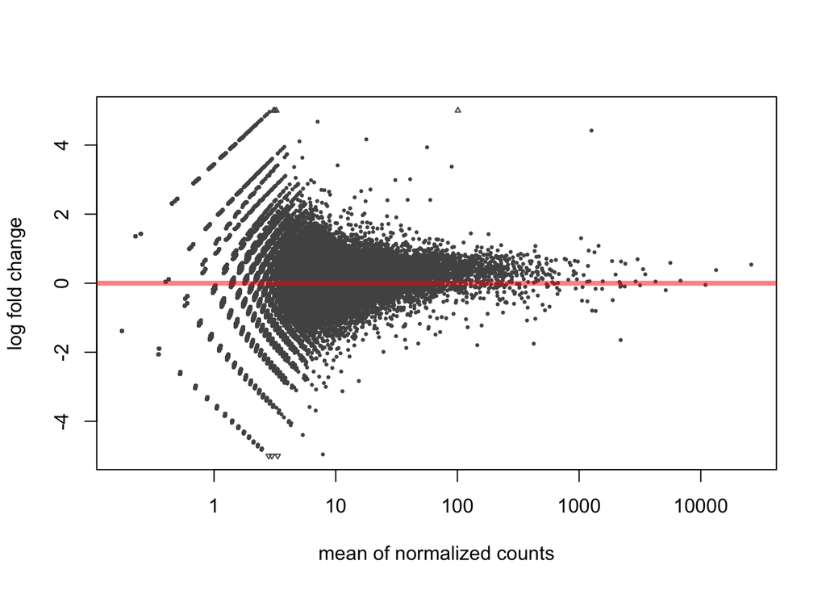

```r
plotMA(res_ctrlBULK, ylim=c(-5,5), alpha = THRES)
```

```r
# "Table" of top diff expr
print('Most differ expr genes of normalized counts')
```

```
## [1] "Most differ expr genes of normalized counts"
```

```r
topgenes <- rownames(res_ctrlBULK)[res_ctrlBULK$padj <= sort(res_ctrlBULK$padj)[75] &!is.na(res_ctrlBULK$padj)] #for downstream anlaysis
res_ctrlBULK[order(res_ctrlBULK$padj)[0:75],] #top genes table
```

```
## log2 fold change (MLE): condition gt vs bulk
## Wald test p-value: condition gt vs bulk
## DataFrame with 75 rows and 6 columns
##                         baseMean      log2FoldChange             lfcSE
##                        <numeric>           <numeric>         <numeric>
## ENSG00000000003 3.03553260083303   -1.63106161174752  2.14837220378767
## ENSG00000000005 1.38121844445872 -0.0407179706517955   2.8818302606084
## ENSG00000000419 3.81335561424086    1.08790639869368  1.79563537182783
## ENSG00000000457 20.1772803271237    0.32099493683658  1.18752047415659
## ENSG00000000460 43.5162487668306   0.691176554802332 0.975112583865335
## ...                          ...                 ...               ...
## ENSG00000004961  3.5418421673966  -0.540172981262353  1.82954997729565
## ENSG00000004975 3.65972932596371   0.354460602225287  1.86127181057146
## ENSG00000005001 9.96490277925191  0.0470336112964892  1.28261997385609
## ENSG00000005007 10.5943809990969  0.0190466452512546  1.29155239386983
## ENSG00000005020 5.73543541848183  -0.510768493622875  1.57285371092002
##                                stat            pvalue              padj
##                           <numeric>         <numeric>         <numeric>
## ENSG00000000003  -0.759208115275317 0.447728072276983 0.999977482983485
## ENSG00000000005 -0.0141292050431864 0.988726900524013 0.999977482983485
## ENSG00000000419   0.605861532782272 0.544606705168905 0.999977482983485
## ENSG00000000457   0.270306865289678 0.786924184149391 0.999977482983485
## ENSG00000000460    0.70881718299903 0.478437933239643 0.999977482983485
## ...                             ...               ...               ...
## ENSG00000004961  -0.295249098393481 0.767803597671706 0.999977482983485
## ENSG00000004975   0.190439999258603 0.848964356279602 0.999977482983485
## ENSG00000005001  0.0366699507688832 0.970748168334267 0.999977482983485
## ENSG00000005007  0.0147470945365103 0.988233947428069 0.999977482983485
## ENSG00000005020  -0.324739986990977 0.745377868164515 0.999977482983485
```

We see there is no significant impact between bulk gt and bulk b2.

# Part 2A. Establish that single cell protocol does impact gexp

To accomblish this we will see if there is a difference in gene expression between bulk (combined GT,B) vs sc (combined enz and mech)

using wald test (because only 2 factor levels). currently not incorporating batch in linear model

```
##              condition
## bulkGT_7319       bulk
## bulkGT_7320       bulk
## bulk_7319         bulk
## bulk_7320         bulk
## sc_mech_7319        sc
## sc_mech_7320        sc
## sc_enz_7319         sc
## sc_enz_7320         sc
```

```
## [1] "mean of normalized counts for all samples"
## [2] "log2 fold change (MLE): condition sc vs bulk"
## [3] "standard error: condition sc vs bulk"
## [4] "Wald statistic: condition sc vs bulk"
## [5] "Wald test p-value: condition sc vs bulk"
## [6] "BH adjusted p-values"
```

```
## [1] "MA plot of normalized counts"
```

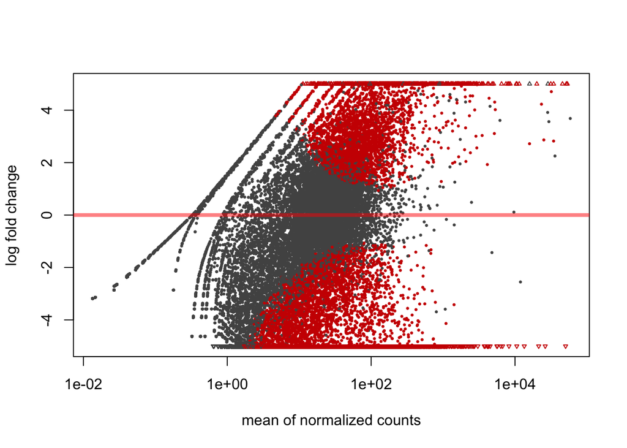

```
## [1] "Most differ expr genes of normalized counts"
```

```
## log2 fold change (MLE): condition sc vs bulk
## Wald test p-value: condition sc vs bulk
## DataFrame with 75 rows and 6 columns
##                         baseMean    log2FoldChange             lfcSE
##                        <numeric>         <numeric>         <numeric>
## ENSG00000251562 51756.1737925222  8.98630446203169  0.30616951848316
## ENSG00000152348 3839.52143352782  -9.0434173215836 0.348244417365916
## ENSG00000150967 1064.35325842896 -8.75771721385383 0.343226425065602
## ENSG00000267598 2042.48580622216 -11.0922655495064 0.451838772029596
## ENSG00000280195 1068.36474012705 -8.92531675431583 0.364043089911855
## ...                          ...               ...               ...
## ENSG00000224086 302.863169378236 -6.67643287264527 0.401356279527952
## ENSG00000272173 313.301926928939 -10.1574245854444 0.610914530242621
## ENSG00000279605 5592.07557422886 -17.8998800628687  1.07959251228598
## ENSG00000254873 739.203506188881 -12.2067011158244 0.736645185787258
## ENSG00000225855 626.493497228483  -9.6621787860415  0.58424930442621
##                              stat                pvalue                  padj
##                         <numeric>             <numeric>             <numeric>
## ENSG00000251562  29.3507482604803 2.33755145803397e-189 8.24080391015296e-185
## ENSG00000152348 -25.9685923753984 1.12135995644759e-148 1.97662119523016e-144
## ENSG00000150967 -25.5158594277231 1.31456455704414e-143 1.54478862980113e-139
## ENSG00000267598 -24.5491671723555 4.41448499838709e-133 3.89070635332846e-129
## ENSG00000280195 -24.5171986549089 9.68404265095494e-133 6.82802479233531e-129
## ...                           ...                   ...                   ...
## ENSG00000224086 -16.6346789951751  3.90844809376817e-62  1.94068209996765e-59
## ENSG00000272173  -16.626588634928  4.47350055674094e-62  2.19039984204646e-59
## ENSG00000279605 -16.5802187947438  9.68754742864311e-62  4.67842187738883e-59
## ENSG00000254873 -16.5706657035693  1.13561587802223e-61  5.41013542753996e-59
## ENSG00000225855 -16.5377668622656  1.96160448964789e-61  9.22058729040623e-59
```

```r
print('Now lets look at the log10(counts) of the data')
```

```
## [1] "Now lets look at the log10(counts) of the data"
```

```
## [1] "size factors applied for norm were:"
```

```
##  bulkGT_7319  bulkGT_7320    bulk_7319    bulk_7320 sc_mech_7319 sc_mech_7320
##    0.2548447    0.2939927    0.1779041    0.3868094    0.6992965    8.5538542
##  sc_enz_7319  sc_enz_7320
##    4.6921780    9.3292434
```

Now let’s take a closer look at the top 75 diff expr genes

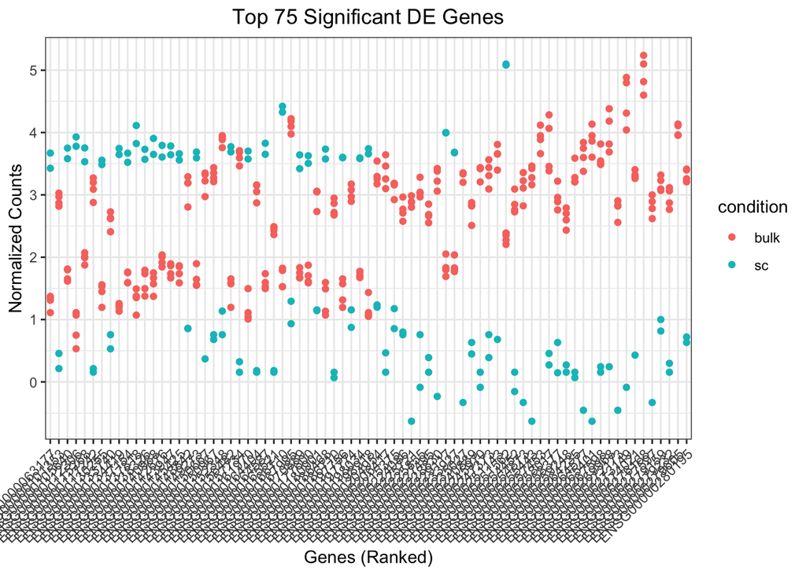

```r
# 1B. get subset of top genes to look at, extract this info from DESeq then subset normalized count matrix
# Reformat
m_tibble <- meta_data %>%
  rownames_to_column(var="samplename") %>%
  as_tibble()
normalized_counts <- normalized_counts_tibble %>%
  data.frame() %>%
  rownames_to_column(var="gene") %>%
  as_tibble()
# Extract
top75_norm <- normalized_counts %>%
        filter(gene %in% topgenes)


# 2. Plot signficant DE genes
# Gathering the columns to have normalized counts to a single column (aka create a col sample name)
gathered <- top75_norm %>%
  gather(colnames(top75_norm)[2:7], key = "samplename", value = "normalized_counts") #2:7 bc headers are gene,then all 6 samples
# melt so that plot will be colored by condition
gathered <- inner_join(m_tibble, gathered,by="samplename")
# Let's apply log 10 to normalized counts + replace inf to NA from log10 transform
newcol <-log10(gathered$normalized_counts)
is.na(newcol) <- sapply(newcol, is.infinite)
gathered$log10_normalized_counts <- newcol
ggplot(gathered) +
        geom_point(aes(x = gene, y = log10_normalized_counts, color = condition)) +
        xlab("Genes (Ranked)") +
        ylab("Normalized Counts") +
        ggtitle("Top 75 Significant DE Genes") +
        theme_bw() +
    theme(axis.text.x = element_text(angle = 45, hjust = 1)) +
    theme(plot.title = element_text(hjust = 0.5))
```

```r
# 3. Heatmap
#plot only signficant genes and display their normalized expression
print('Heatmap of TOP GENE log10 normalized counts')
```

```
## [1] "Heatmap of TOP GENE log10 normalized counts"
```

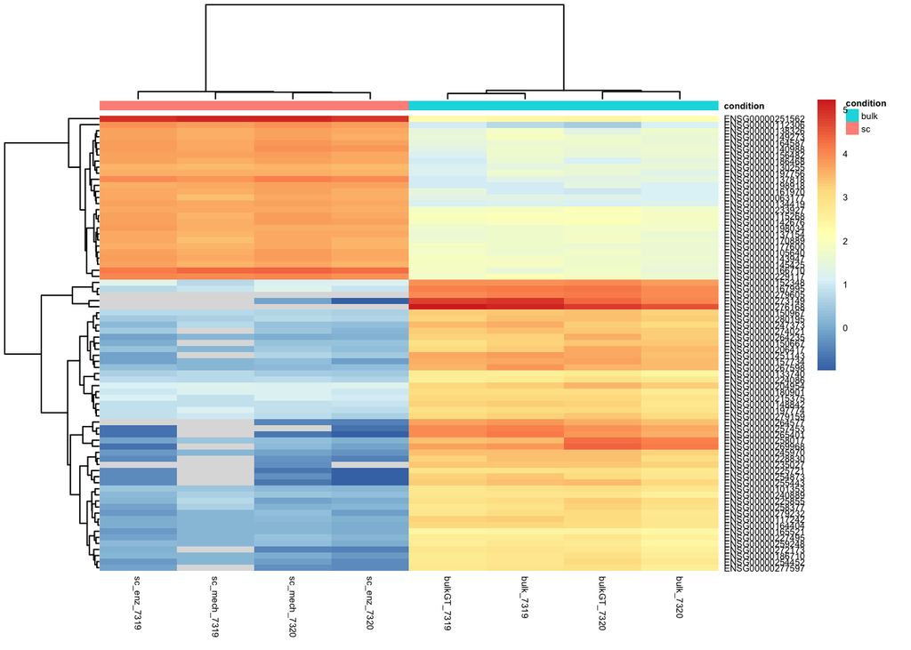

```r
# Reformat
annotation <- m_tibble %>%data.frame(row.names = "samplename")
mat<- top75_norm %>% column_to_rownames(var = "gene")
# Let's apply log 10 to normalized counts + replace inf to NA from log10 transform
mat <- log10(mat)
is.na(mat) <- sapply(mat, is.infinite)
pheatmap(mat,
         cluster_rows = T,
         cluster_cols = T,
         show_rownames = T,
         border_color = NA,
         annotation = annotation,
         fontsize = 5)
```

```r
print('Now lets look at all genes not just top 75')
```

```
## [1] "Now lets look at all genes not just top 75"
```

```r
# 3. Heatmap
#plot only signficant genes and display their normalized expression
print('Heatmap of ALL log 10 normalized counts')
```

```
## [1] "Heatmap of ALL log 10 normalized counts"
```

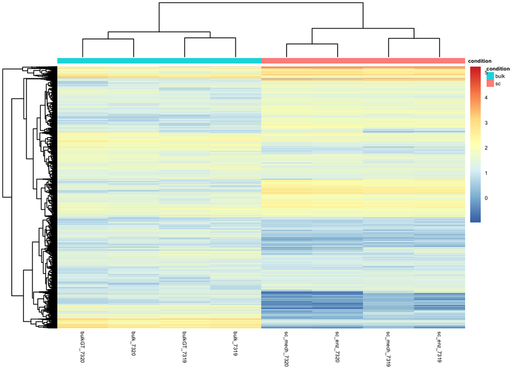

```
### note underlying assumption is that we are just removing genes where at least one sample has inf val after log transform. this needs to be patched to handle instead of remove, but for the purposes of showing global batch effect it won't impact it for WCS. BUT we must address for final analysis
```

```r
# Reformat
annotation <- m_tibble %>%data.frame(row.names = "samplename")
mat<- normalized_counts %>% column_to_rownames(var = "gene")
# Let's apply log 10 to normalized counts + replace inf to 0 from log10 transform
mat <- log10(mat)
# mat <- mat[1:20000,]
is.na(mat) <- sapply(mat, is.infinite)
mat <- na.omit(mat)
pheatmap(mat,
         cluster_rows = T,
         cluster_cols = T,
         show_rownames = F,
         border_color = NA,
         annotation = annotation,
         fontsize = 5)
```

# Part 2B. Comparing scRNA-mech pseudo, scRNA-enz pseudo, and bulk - normalized

using LRT (not wald) bc factor level>2. not yet incorporate batch in linear model

```r
############################
# Create count matrices for DGE
############################
# Combine mech samples
flat_matrix_mech <- merge(mech1, mech2, by =0, all=TRUE) #merge by rowname
colnames(flat_matrix_mech) <- c("ensID",scmech_base_names)
# Combine enz samples
flat_matrix_enz <- merge(enz1, enz2, by =0, all=TRUE) #merge by rowname
colnames(flat_matrix_enz) <- c("ensID",scenz_base_names)
# Combine mech and enz samples
flat_matrix_ALL <- merge(flat_matrix_mech, flat_matrix_enz, by ='ensID', all=TRUE) #merge by rowname
# Combine mech, enz, bulk
flat_matrix_ALL <- merge(flat_matrix_BULK, flat_matrix_ALL, by='ensID', all=TRUE)
# Replace NA --> 0
flat_matrix_ALL[is.na(flat_matrix_ALL)]=0
# Now that have combined properly fix so that rowname are genes
flat_matrix_ALL <- column_to_rownames(flat_matrix_ALL, var='ensID')


############################
# Create meta data table of which samples are which treatment - needed for Deseq2
#############################
# Grab samples in order
samples <- colnames(flat_matrix_ALL)
# Create condition vector and type
condition <- c('bulk','bulk', 'mech', 'mech', 'enz', 'enz')
meta_data <- as.data.frame(condition)
rownames(meta_data) <- samples
meta_data
```

```
##              condition
## bulk_7319         bulk
## bulk_7320         bulk
## sc_mech_7319      mech
## sc_mech_7320      mech
## sc_enz_7319        enz
## sc_enz_7320        enz
```

```r
#### consider removing
# # Remove gene rows that are lowly expr in samples - filter low counts <10 ct
# flat_matrix_ctrlBULK <- flat_matrix_ctrlBULK[rowSums(flat_matrix_ctrlBULK > 10) != 0, ]
```

```r
#####################
# DGE
#####################
dds_obj_ALL <- DESeqDataSetFromMatrix(countData = flat_matrix_ALL, colData = meta_data, design = ~condition)

# DGE based on neg binom distr
dds_ALL <- DESeq(dds_obj_ALL, test ='LRT', reduced=~1)
res_ALL <- results(dds_ALL, alpha=THRES, pAdjustMethod = 'BH')
( mcols(res_ALL)$description ) # info
```

```
## [1] "mean of normalized counts for all samples"
## [2] "log2 fold change (MLE): condition mech vs bulk"
## [3] "standard error: condition mech vs bulk"
## [4] "LRT statistic: '~ condition' vs '~ 1'"
## [5] "LRT p-value: '~ condition' vs '~ 1'"
## [6] "BH adjusted p-values"
```

```r
#MA plot
print('MA plot of normalized counts')
```

```
## [1] "MA plot of normalized counts"
```

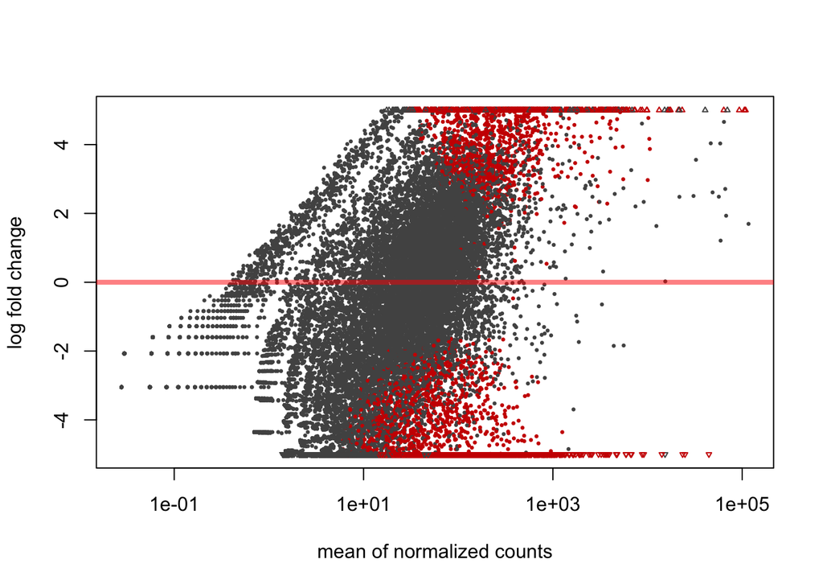

```r
plotMA(res_ALL, ylim=c(-5,5), alpha = THRES)
```

```r
# "Table" of top diff expr
print('Most differ expr genes of normalized counts')
```

```
## [1] "Most differ expr genes of normalized counts"
```

```r
topgenes <- rownames(res_ALL)[res_ALL$padj <= sort(res_ALL$padj)[75] &!is.na(res_ALL$padj)]
#downstream anlaysis
res_ALL[order(res_ALL$padj)[0:75],] #top genes table
```

```
## log2 fold change (MLE): condition mech vs bulk
## LRT p-value: '~ condition' vs '~ 1'
## DataFrame with 75 rows and 6 columns
##                         baseMean    log2FoldChange             lfcSE
##                        <numeric>         <numeric>         <numeric>
## ENSG00000204954 1037.98514158895 -6.95083069367173 0.573091895181789
## ENSG00000157734 2084.80971962768 -11.0487365229822 0.893720744817328
## ENSG00000264235 951.898222777618 -10.5866606645442 0.895578358822384
## ENSG00000150967 1052.07935029972 -8.66632058441681 0.709970110710348
## ENSG00000251562 105576.182867291  9.24093929302937 0.519415496681053
## ...                          ...               ...               ...
## ENSG00000215424 298.929469045151 -6.98303974941298 0.850098659710736
## ENSG00000263069 355.634138691815 -6.06767760076323 0.775600472179659
## ENSG00000256013 158.658386142509 -10.9704116373702  1.42856084349311
## ENSG00000235016 213.289396490607 -9.12961058616158  1.15696747013109
## ENSG00000115486 383.127095757338 -4.09872428291164 0.501865193980538
##                             stat               pvalue                 padj
##                        <numeric>            <numeric>            <numeric>
## ENSG00000204954   182.8166496935 2.00386711874282e-40 4.63754967290651e-36
## ENSG00000157734 180.332792117294 6.93795915311159e-40 6.53085372205545e-36
## ENSG00000264235 179.934722047816 8.46586923310131e-40 6.53085372205545e-36
## ENSG00000150967 176.248874147905 5.34617607393671e-39 3.09316382197793e-35
## ENSG00000251562 166.929351141006 5.64614420319504e-37 2.61337430589086e-33
## ...                          ...                  ...                  ...
## ENSG00000215424 93.4710807905757 5.04676052668721e-21 1.64503068829749e-18
## ENSG00000263069 93.2982807365196 5.50219214481949e-21 1.76857267788274e-18
## ENSG00000256013 92.2613960260787 9.24043479087112e-21 2.92947099130315e-18
## ENSG00000235016 91.9991437430016 1.05351267801963e-20 3.29478971721733e-18
## ENSG00000115486 91.8745392307627 1.12123666853862e-20 3.45983736266523e-18
```

Now let’s look at the log10(counts) of the data

```r
##############
# Visualization
##############
# First, Extract normalized count matrix used by DESeq
    # estimating size factors is auto in DESEQ() but
    # we have to do this manually to extract the normalized count matrix it produces
    # Normalization method= deseq median or ratios method
dds <- DESeqDataSetFromMatrix(countData = flat_matrix_ALL, colData = meta_data, design = ~condition)
dds<- estimateSizeFactors(dds)
('size factors applied for norm were:')
```

```
## [1] "size factors applied for norm were:"
```

```r
(sizeFactors(dds)) #good for record keeping
```

```
##    bulk_7319    bulk_7320 sc_mech_7319 sc_mech_7320  sc_enz_7319  sc_enz_7320
##    0.1106848    0.2366106    0.4630043    5.6077567    3.0254173    6.0093794
```

```r
normalized_counts_tibble <- counts(dds, normalized=TRUE)
#write.table(normalized_counts_tibble,file="/Users/leejor/Ellrott_Lab/04_CSBC/cell-dissociation/data/03_compare-bulk_scrna/scrna2bulk/normalized_counts--ALL.txt", sep="\t", quote=F, col.names=NA)
```

Now let’s take a closer look at the top 75 diff expr genes

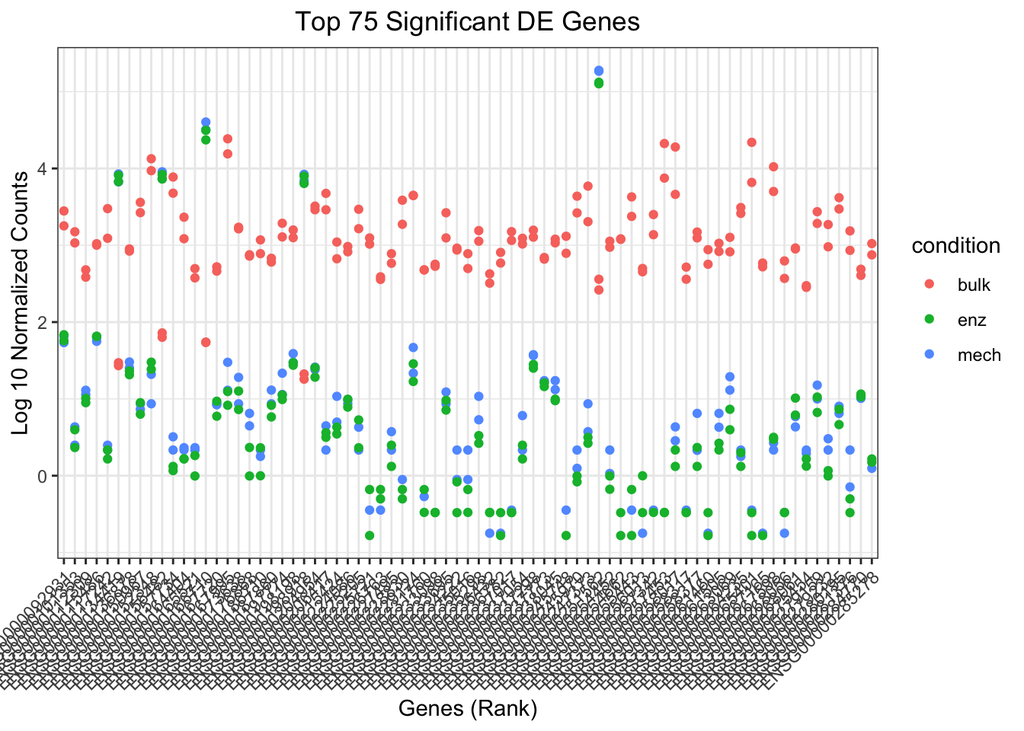

```r
# Get subset of top genes to look at, extract this info from DESeq then subset normalized count matrix
# Reformat
m_tibble <- meta_data %>%
  rownames_to_column(var="samplename") %>%
  as_tibble()
normalized_counts <- normalized_counts_tibble %>%
  data.frame() %>%
  rownames_to_column(var="gene") %>%
  as_tibble()
# Extract
top75_norm <- normalized_counts %>%
        filter(gene %in% topgenes)


# 2. Plot signficant DE genes
# Gathering the columns to have normalized counts to a single column (aka create a col sample name)
gathered <- top75_norm %>%
  gather(colnames(top75_norm)[2:7], key = "samplename", value = "normalized_counts") #2:7 bc headers are gene,then all 6 samples
# melt so that plot will be colored by condition
gathered <- inner_join(m_tibble, gathered,by="samplename")
# Let's apply log 10 to normalized counts + replace inf to NA from log10 transform
newcol <-log10(gathered$normalized_counts)
is.na(newcol) <- sapply(newcol, is.infinite)
gathered$log10_normalized_counts <- newcol
#plot
ggplot(gathered) +
        geom_point(aes(x = gene, y = log10_normalized_counts, color = condition)) +
        xlab("Genes (Rank)") +
        ylab("Log 10 Normalized Counts") +
        ggtitle("Top 75 Significant DE Genes") +
        theme_bw() +
    theme(axis.text.x = element_text(angle = 45, hjust = 1)) +
    theme(plot.title = element_text(hjust = 0.5))
```

```r
# 3. Heatmap
#plot only signficant genes and display their normalized expression
print('Heatmap of TOP GENE log 10 normalized counts')
```

```
## [1] "Heatmap of TOP GENE log 10 normalized counts"
```

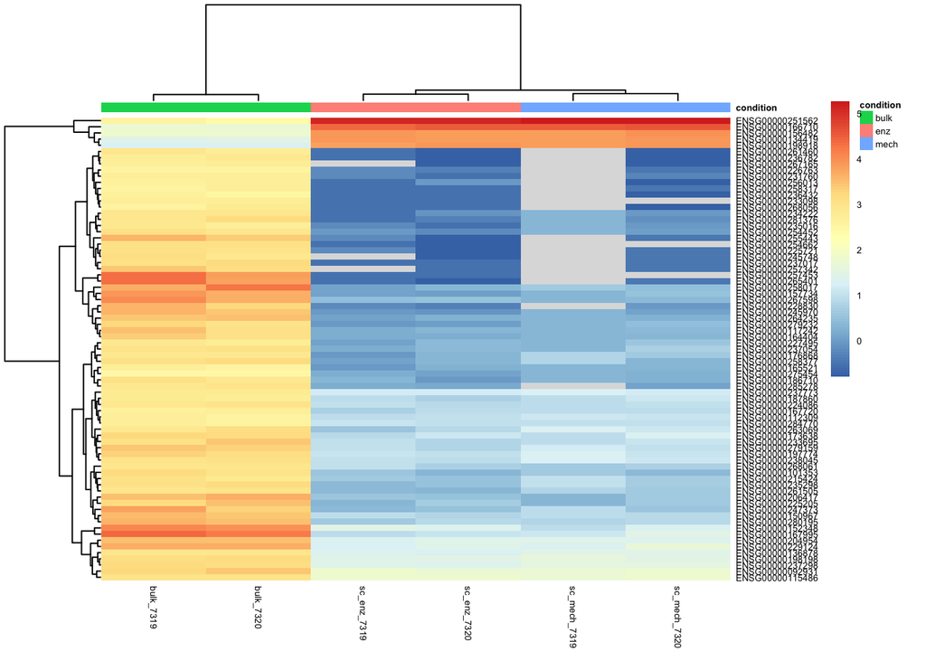

```r
# Reformat
annotation <- m_tibble %>%data.frame(row.names = "samplename")
mat<- top75_norm %>% column_to_rownames(var = "gene")
# Let's apply log 10 to normalized counts + replace inf to NA from log10 transform
mat <- log10(mat)
is.na(mat) <- sapply(mat, is.infinite)
pheatmap(mat,
         cluster_rows = T,
         cluster_cols = T,
         show_rownames = T,
         border_color = NA,
         annotation = annotation,
         fontsize = 5)
```

```r
print('Now lets look at all genes not just top 75')
```

```
## [1] "Now lets look at all genes not just top 75"
```

```r
# 3. Heatmap
#plot only signficant genes and display their normalized expression
print('Heatmap of ALL log 10 normalized counts')
```

```
## [1] "Heatmap of ALL log 10 normalized counts"
```

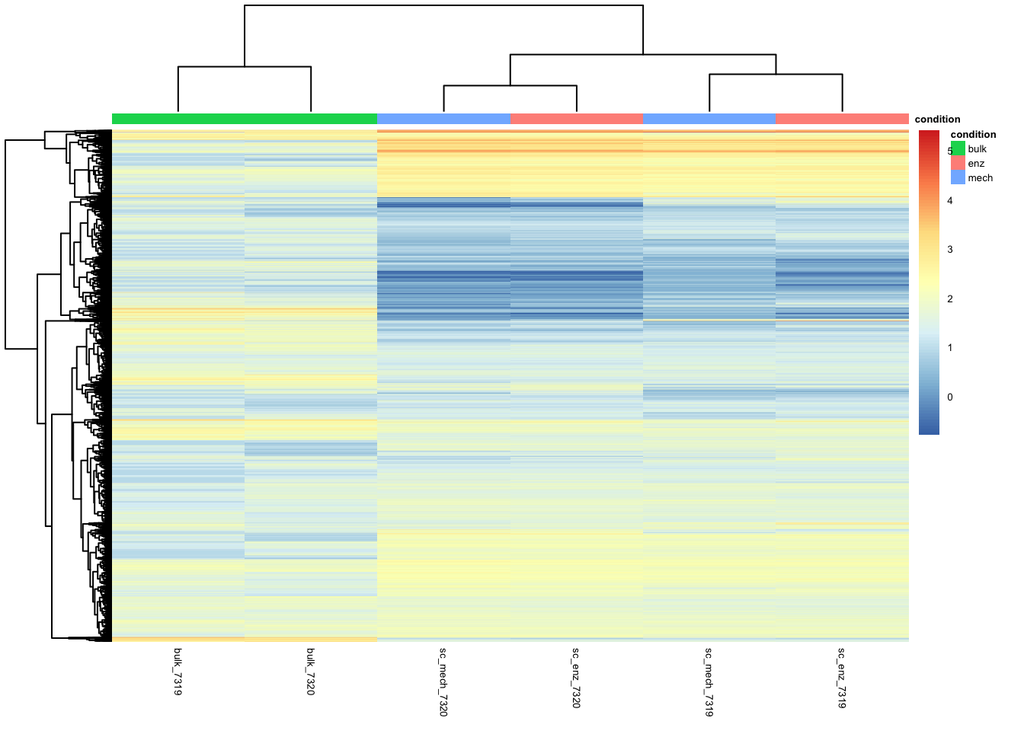

```
### note underlying assumption is that we are just removing genes where at least one sample has inf val after log transform. this needs to be patched to handle instead of remove, but for the purposes of showing global batch effect it won't impact it for WCS. BUT we must address for final analysis
```

```r
# Reformat
annotation <- m_tibble %>%data.frame(row.names = "samplename")
mat<- normalized_counts %>% column_to_rownames(var = "gene")
# Let's apply log 10 to normalized counts + replace inf to 0 from log10 transform
mat <- log10(mat)
# mat <- mat[1:20000,]
is.na(mat) <- sapply(mat, is.infinite)
mat <- na.omit(mat)
pheatmap(mat,
         cluster_rows = T,
         cluster_cols = T,
         show_rownames = F,
         border_color = NA,
         annotation = annotation,
         fontsize = 5)
```

# Part 3: Tumor vs matched normal

Comparing differences between bulk and N (excluding GT from this analysis)

```r
############################
# Create count matrices for DGE
############################
# Combine matrices
flat_matrix_ctrlBULK <- merge(flat_matrix_BULK, flat_matrix_BULK_norm, by='ensID', all=TRUE)
# Replace NA --> 0
flat_matrix_ctrlBULK[is.na(flat_matrix_ctrlBULK)]=0
# Now that have combined properly fix so that rowname are genes
flat_matrix_ctrlBULK <- column_to_rownames(flat_matrix_ctrlBULK, var='ensID')

############################
# Create meta data table of which samples are which treatment - needed for Deseq2
#############################
# Grab samples in order
samples <- colnames(flat_matrix_ctrlBULK)

# Create condition vector and type
condition <- c('bulk','bulk', 'norm', 'norm')
meta_data <- as.data.frame(cbind(condition) )
rownames(meta_data) <- samples
meta_data
```

```
##                condition
## bulk_7319           bulk
## bulk_7320           bulk
## bulk_norm_7319      norm
## bulk_norm_7320      norm
```

```r
# # Remove gene rows that are lowly expr in samples - filter low counts <10 ct
# flat_matrix_ctrlBULK <- flat_matrix_ctrlBULK[rowSums(flat_matrix_ctrlBULK > 10) != 0, ]
```

**Code below throws an error, will need to revisit this to fix**

`Error in estimateSizeFactorsForMatrix(counts(object), locfunc = locfunc, : every gene contains at least one zero, cannot compute log geometric means`

```
#####################
# DGE
#####################
dds_obj_ctrlBULK <- DESeqDataSetFromMatrix(countData = flat_matrix_ctrlBULK, colData = meta_data, design = ~ condition)
# DGE based on neg binom distr
dds_ctrlBULK <- DESeq(dds_obj_ctrlBULK, test ='Wald')
```